# Exploring genome variation using GEMINI framework in R

November 30, 2016

## Prerequisites

- R and R-studio
- Download and decompress GEMINI database (large file, 83MB) https://drive.google.com/open?id=0B_bLL10GwDnsaXNNOW5EUDV0QjQ
- Download and decompress additional tables https://drive.google.com/open?id=0B_bLL10GwDnsblgySWZjeHFFSUE
- Install packages: RSQLite, plyr
- Explore documentation: http://gemini.readthedocs.io/en/latest/
- Read the article: http://journals.plos.org/ploscompbiol/article?id=10.1371/journal.pcbi.1003153
- R code for the tutorial: https://github.com/naumenko-sa/tutorials/blob/master/gemini_tutorial.R

## 'Lazy bioinformatics' approach

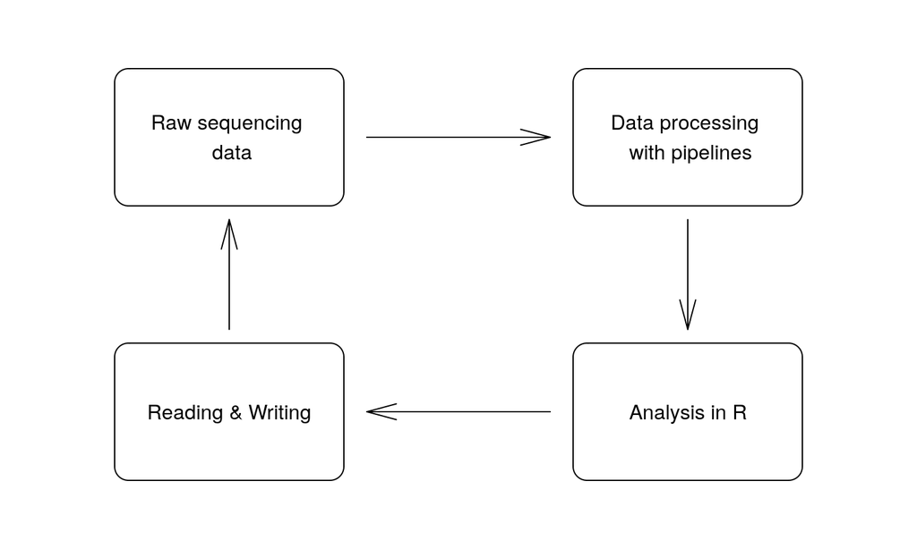

Only possible for simple analyses: Variants in whole exome sequencing, RNA-seq, Differential Expression

## What could we say about this variant?

### chr19 38976331 G A

## chr19 38976331 G A

### What should we figure out first?

- Species: *H.sapiens*, *Mus musculus*, *Drosophila melanogaster*?

### What should we figure out second?

- https://www.ncbi.nlm.nih.gov/grc/human
- http://grch37.ensembl.org
- http://www.ensembl.org/index.html

## Ensembl Variant Effect Predictor

http://grch37.ensembl.org/Homo_sapiens/Tools/VEP

### Other options

- SNPeff
- Annovar

## dbSNP

### Look for rs146504767

https://www.ncbi.nlm.nih.gov/projects/SNP/

## Human Gene Mutation Database (HGMD)

- RYR1
- CM104331
- http://www.hgmd.cf.ac.uk
- Pro version is much better but pricy.

## What if we have more than one variant?

- [Stitziel et al. Computational and statistical approaches to analyzing variants identified by exome sequencing](https://genomebiology.biomedcentral.com/articles/10.1186/gb-2011-12-9-227)
- [Exome aggregation consortium](http://www.nature.com/nature/journal/v536/n7616/full/nature19057.html)
- clunky vcf file

[output not shown]

## How to organize this information in a neat format?

- Use dataframe in R or even a database
- GEMINI database
  - https://gemini.readthedocs.io/en/latest/
  - Paila U, Chapman BA, Kirchner R, Quinlan AR (2013) GEMINI: Integrative Exploration of Genetic Variation and Genome Annotations. PLoS Comput Biol 9(7): e1003153. doi:10.1371/journal.pcbi.1003153 cited by 74
  - http://journals.plos.org/ploscompbiol/article?id=10.1371/journal.pcbi.1003153

## What is database?

- Database is a collection of related dataframes (tables);
- GEMINI uses SQLite database which does not require database server or database engine;
- database slang:
  - dataframe = table
  - column = field
  - select * from [table_name] where [condition];
- Web Interface to plot database schemas: http://ondras.zarovi.cz/sql/demo/?keyword=default

## Gemini database schema

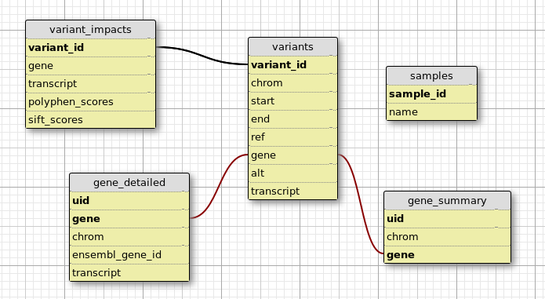

http://gemini.readthedocs.io/en/latest/content/database_schema.html

## Gemini detailed

- [Gemini framework](http://journals.plos.org/ploscompbiol/article/figure/image?size=large&download=&id=10.1371/journal.pcbi.1003153.g001)
- [Gemini tools](http://journals.plos.org/ploscompbiol/article/figure/image?size=large&download=&id=10.1371/journal.pcbi.1003153.g002)
- [Gemini web interface](http://journals.plos.org/ploscompbiol/article/figure/image?size=large&download=&id=10.1371/journal.pcbi.1003153.g003)

## How to load your variants into the GEMINI database?

- Ask your bioinformatics provider to send results in the GEMINI format;
- Ask CCM to convert vcf2gemini;
- Convert
  - [with gemini load (linux)](http://gemini.readthedocs.io/en/latest/content/preprocessing.html)
  - [vcf2db.py](https://github.com/quinlan-lab/vcf2db)
- Use bcbio pipeline system – it outputs GEMINI and vcf.

## Bcbio pipelines

- open source, community supported
- developed mainly by Harvard T.Chan Medical School Bioinformatics Core
- validated
- well documented
- easy to install and run
- Pipelines supported: (variant calling,cancer variants,structural variants, RNA-seq,smallRNA-seq,ChIP-seq)
- Resources
  - https://bcbio-nextgen.readthedocs.io/en/latest/
  - https://github.com/chapmanb/bcbio-nextgen
  - https://bcb.io

## 'Lazy bioinformatics' approach

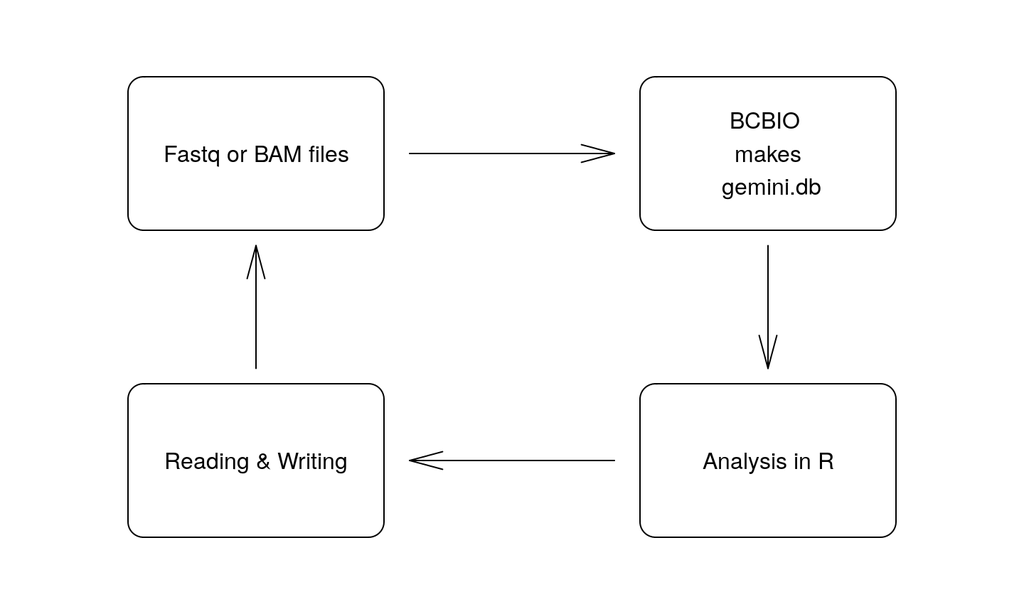

Only possible for simple analyses: Variants in whole exome sequencing, RNA-seq, Differential Expression

## Let us try GEMINI!

https://github.com/naumenko-sa/tutorials/blob/master/gemini_tutorial.R

## Additional columns not present in GEMINI

- OMIM gene description (registration required)
- Orphanet status
- exac pLi score
- exac missense score
- imprinting status
- pseudoautosomal genes

## GTS field problem

- Gemini stores genotype information in the python-specific compressed format
- It is not easy to decompress in R
- Solution:
  - gemini2txt first and then load to R https://github.com/naumenko-sa/bioscripts/blob/master/gemini2txt.single_sample.mh.sh
  - use new loader https://github.com/quinlan-lab/vcf2db

## More tutorials on GEMINI from Aaron Quinlan

https://speakerdeck.com/arq5x/